# 000_HelloWorldС

# Отзывы читателей

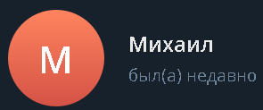

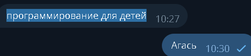

# По просьбам учащихся

[figure not shown]

# Notepad++ C-Free *.Bat F5

[figure not shown]

Теперь кодим в [Notepad++](https://notepad-plus-plus.org/). Сохраняем через сочетание клавиш `Ctrl+S`. Запускаем через `F5; Enter`, в качестве параметров запуска подсовываем батник.

Пользуемся правильной кодировкой файла.</br> Для батника это : `Кодировки/Кодировки/Кирилица/OEM866` </br> Для main.c файла это : `Кодировки/Кодировки/Кирилица/Windows-1257` </br>

```python
%%writefile Start.Bat
:: отключение предварительног вывода команды в консоль перед исполнением
@echo off
:: Переход в папку, к которой находится исполняемый батник
cd %~dp0
:: Находим в недрах С-Free компилятор и шлем свой файлик туда.
:: Помечаем пораметром название файла после компиляции
"C:\Program Files (x86)\C-Free 5\mingw\bin\c++.exe" main.c -o Start.exe
:: запускаем результат компиляции
Start.exe
:: 5 секунд радуемся осторожненько
TIMEOUT /T 5
:: аккуратно выключаем батничеГ.
exit /b
```

```
Writing Start.Bat
```

# jupiter notebook PYTHON C-Free *.Bat прямо в лекции

Проблемы: кодировки и попытка чтения с консоли.

Что интерестно. [В интернете используется в основном инструкция](https://envyen.com/posts/2021-06-27-C-CPP-Jupyter-Notebook-Windows/).

В CMD; PowerShell; [ставится Linux в Windows с помощью WSL](https://learn.microsoft.com/ru-ru/windows/wsl/install)

# Config

```python
from IPython.core.magic import (register_line_magic,register_cell_magic)
def Debag_Lang_Cpp(code):
    with open('main.c', mode='w') as file:file.write(code)
    !"C:\Program Files (x86)\C-Free 5\mingw\bin\\c++.exe" main.c -o Start.exe
    !Start.exe<inPut.txt
@register_line_magic
def Cpp_line(line):
    Debag_Lang_Cpp(line)
@register_cell_magic
def Cpp(line,cell):
    Debag_Lang_Cpp(cell)
@register_cell_magic
def Input(line,cell):
    with open('inPut.txt', mode='w') as file:file.write(cell)
cInPut(None," \n")
```

```python
%%Cpp
#include <stdio.h>
int main(int argc, char *argv[])
{
	printf("Hello C-Free!\n");
	int a = 2;
	printf("a = %d\n", a);
	return 0;
}
```

```
Hello C-Free!
a = 2
```

```python
%%Input
17
w
```

```python
%%Cpp
#include <stdio.h>
int main(int argc, char *argv[])
{
	printf("Hello C-Free!\n");
	int age=0;
	scanf("%d\n", &age);
	printf("age = %d\n", age);
	int res = 0;res=getchar();
    printf("res = <%c>\n", res);
	return 0;
}
```

```
Hello C-Free!
age = 17
res = <w>
```

Остается нерешонной проблема со вводом данных с консоли. При попытке чтения с консоли происходит зависание. На данном этапе это, предположительно, не критично.

# Отзывы читателей

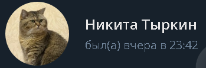

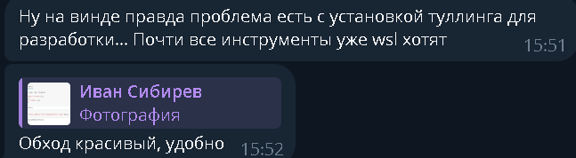

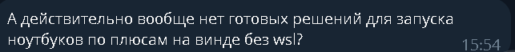

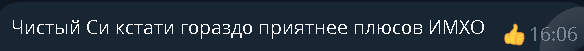

# Подведем итоги...

[figure not shown]